# Module 3 - Plan d’apprentissage

STT-1100 Introduction à la science des données

# Objectifs du module

# Lectures initiales

## 📘 Lectures à faire avant l’aventure

Dans ce module, nous allons explorer les variables **catégoriques** et la **visualisation adaptée** à ce type de données. Deux lectures sont proposées pour vous préparer :

- [**R for Data Science – Strings**](https://r4ds.hadley.nz/strings.html)  
  Ce chapitre vous introduit à la manipulation des chaînes de caractères avec le package `stringr`.  
  > 📝 **Note** : Bien que ce chapitre soit plus largement utilisé au module 4, certaines fonctions utiles comme `str_detect()` ou `str_to_lower()` peuvent déjà vous aider pour nettoyer ou préparer des variables catégoriques.
- [**Introduction to Modern Statistics – Chapitre 6 : Explore categorical data**](https://openintro-ims.netlify.app/explore-categorical)  
  Ce chapitre de **IMS** présente les concepts statistiques associés aux données catégoriques. On y parle notamment de tableaux de fréquence, de proportions et des façons de représenter visuellement ce type de variables.

Prenez le temps de parcourir ces deux ressources. Elles vous seront utiles pour comprendre comment traiter les **données qualitatives**, tant du point de vue **statistique** que **pratique**.

# Aventure

Aventure 3

# Défi

Au terme de ce module, **vous endosserez le rôle de journaliste de données** pour *Le Courrier Gourmand*.  
Votre mission :

1. **Explorer et nettoyer** le jeu `listecondamnation` (infractions alimentaires au Québec).
2. **Extraire des faits marquants** (top infractions, montants d’amendes, comparaison Montréal / hors-Montréal).
3. **Illustrer vos analyses** par au moins **deux visuels** (un graphique de catégories + la carte des amendes).
4. **Rédiger un article Quarto (HTML)** clair et accrocheur : chapeau ➜ contexte ➜ méthodologie ➜ résultats ➜ recommandations.
5. **Citer deux chiffres narratifs** et **intégrer une courte citation d’Alexandre** pour humaniser la conclusion.

> **À remettre** : le fichier `.qmd` et le HTML généré, livrés via votre dépôt GitHub avant la date limite.

## 📝 Grille d’évaluation

Votre article sera évalué selon les critères suivants. Assurez-vous de bien respecter le canevas fourni et les consignes données.

| Critère | Excellent (3) | Satisfaisant (2) | À améliorer (1) | Commentaire |
| --- | --- | --- | --- | --- |
| **📰 Chapeau introductif** | Accroche percutante, angle clair, chiffres clés bien choisis | Présent mais peu engageant ou peu clair | Absent ou très vague |  |
| **📊 Contexte & présentation des données** | Source bien identifiée, pertinence expliquée, limites évoquées | Contexte partiel ou explication sommaire | Source absente ou non justifiée |  |
| **🧪 Méthodologie (section sans code)** | Démarche bien résumée, claire et logique | Présente mais confuse ou trop technique | Absente ou très floue |  |
| **📈 Résultat clé #1 (graphique + interprétation)** | Visuel clair, bonne interprétation, apport analytique évident | Visuel ou commentaire peu approfondi | Visuel ou analyse absente |  |
| **📊 Résultat clé #2 (graphique + interprétation)** | Visuel pertinent, insight bien formulé | Visuel correct mais analyse faible | Résultat peu exploité ou manquant |  |
| **📉 Résultat clé #3 (graphique + interprétation)** | Résultat original ou complémentaire, bien expliqué | Présent mais peu développé | Manquant ou superficiel |  |
| **🧠 Discussion (section 4)** | Réflexion critique, mise en perspective des résultats | Discussion partielle ou descriptive | Discussion absente ou sans valeur ajoutée |  |
| **✅ Conclusion & recommandations** | Messages d’action clairs, utiles, bien formulés | Messages présents mais peu convaincants | Peu clairs ou hors sujet |  |
| **🗣️ Chiffres narratifs + citation d’Alexandre** | Deux chiffres bien choisis + citation bien intégrée | Un des éléments présent seulement | Aucun ou mal intégré |  |
| **📂 Qualité du rendu (Quarto + dépôt GitHub)** | `.qmd` fonctionnel, HTML lisible, dépôt propre et complet | Quelques problèmes techniques ou dépôt désorganisé | Exécution impossible ou rendu partiel/absent |  |

🧮 **Total sur 30 points** : `XX / 30`

> ✍️ *N’oubliez pas de relire la checklist en fin de template avant de publier votre article.*

# Exercices de consolidation

```r
# Charger les librairies nécessaires
library(tidyverse)
library(stringr)
```

### ❓ Exercice 1 – Identifier les variables catégoriques

Voici un petit jeu de données :

```r
data <- tibble::tibble(
  sexe = c("Homme", "Femme", "Femme", "Homme", "Homme"),
  age = c(25, 32, 29, 40, 23),
  région = c("Est", "Ouest", "Est", "Nord", "Sud")
)
```

> Parmi les trois variables ci-dessus, lesquelles sont catégorielles ?

**✅ Réponse**

Les variables `sexe` et `région` sont **catégorielles**. `age` est **numérique**.

### ❓ Exercice 2 – Tableau de fréquence

Crée un tableau de fréquence pour la variable `sexe`.

**💡 Piste**

Utilise `count()` du package `dplyr`.

**✅ Solution**

```r
data %>% count(sexe)
```

```
# A tibble: 2 × 2
  sexe      n
  <chr> <int>
1 Femme     2
2 Homme     3
```

### ❓ Exercice 3 – Proportions

Calcule les pourcentages pour chaque modalité de la variable `région`.

**💡 Piste**

Ajoute une colonne avec `mutate(n / sum(n))`.

**✅ Solution**

```r
data %>% count(région) %>% mutate(pourcentage = n / sum(n) * 100)
```

```
# A tibble: 4 × 3
  région     n pourcentage
  <chr>  <int>       <dbl>
1 Est        2          40
2 Nord       1          20
3 Ouest      1          20
4 Sud        1          20
```

### ❓ Exercice 4 – Barplot d’une variable catégorielle

Fais un barplot représentant la variable `région`.

**💡 Piste**

Utilise `geom_bar()` avec `aes(x = région)`.

**✅ Solution**

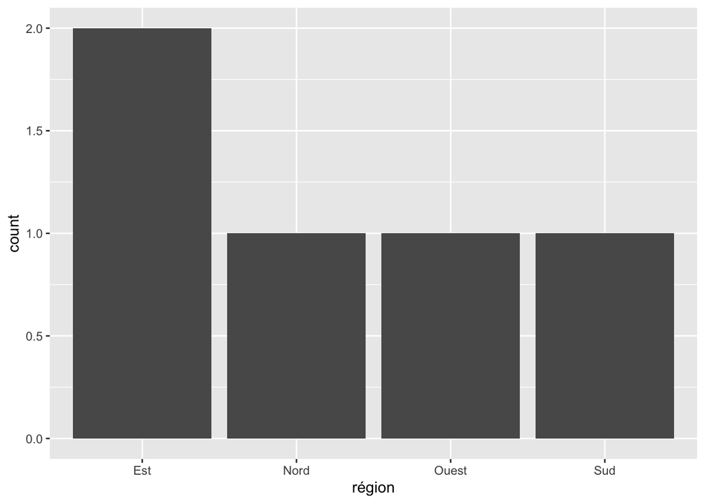

```r
ggplot(data, aes(x = région)) + geom_bar()
```

### ❓ Exercice 5 – Comparaison de deux variables catégorielles

Ajoute une couleur par `sexe` dans le graphique précédent.

**✅ Solution**

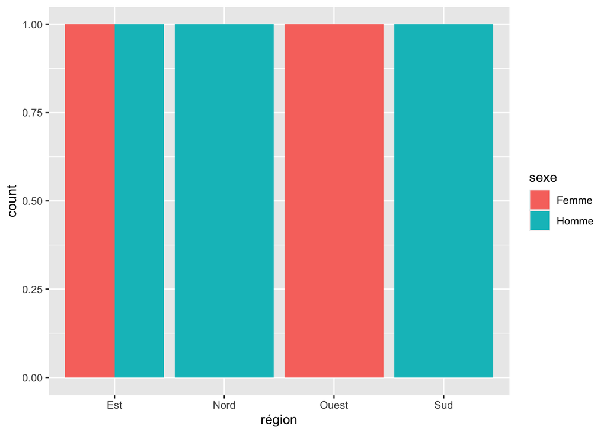

```r
ggplot(data, aes(x = région, fill = sexe)) + geom_bar(position = "dodge")
```

### ❓ Exercice 6 – Nettoyer une variable catégorielle

Voici une variable catégorielle incohérente :

```r
reponses <- c("Oui", "oui", "Non", "non", "OUI", "NON")
```

Nettoie cette variable pour que toutes les réponses soient en minuscules **et sans doublons**.

**✅ Solution**

```r
unique(str_to_lower(reponses))
```

```
[1] "oui" "non"
```

### ❓ Exercice 7 – Tableau croisé

Voici un autre jeu de données :

```r
data2 <- tibble(
  fumeur = c("Oui", "Non", "Non", "Oui", "Oui", "Non", "Non"),
  sport = c("Oui", "Oui", "Non", "Non", "Oui", "Non", "Non")
)
```

Crée un tableau croisé (contingence) entre les deux variables.

**✅ Solution**

```r
data2 %>% count(fumeur, sport) %>% pivot_wider(names_from = sport, values_from = n, values_fill = 0)
```

```
# A tibble: 2 × 3
  fumeur   Non   Oui
  <chr>  <int> <int>
1 Non        3     1
2 Oui        1     2
```

### ❓ Exercice 8 – Pour aller plus loin : Mosaic plot

Utilise le package `ggplot2` (ou `ggmosaic` si disponible) pour représenter visuellement la relation entre `fumeur` et `sport`.

**✅ Solution avec ggplot2**

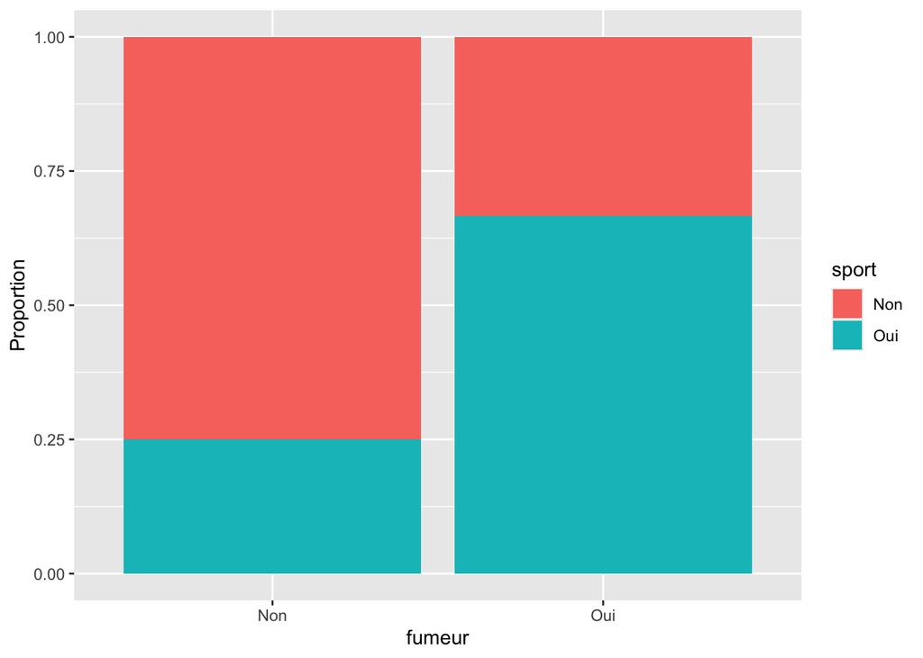

```r
# En regroupant en barres groupées pour une approximation
ggplot(data2, aes(x = fumeur, fill = sport)) +
  geom_bar(position = "fill") +
  ylab("Proportion")
```

## 📦 Problèmes

### 🐧 Exercice 9 – Palmer Penguins

On utilise le jeu de données `penguins` du package `palmerpenguins`.

- Variable catégorielle : `species`, `island`, `sex`
- Variable numérique : `flipper_length_mm`, `body_mass_g`

Questions : 1. Crée un tableau de fréquence pour `species` 2. Visualise la distribution des espèces par île 3. Compare les sexes pour chaque espèce

**✅ Solution**

```r
library(palmerpenguins)
penguins %>% count(species)
```

```
# A tibble: 3 × 2
  species       n
  <fct>     <int>
1 Adelie      152
2 Chinstrap    68
3 Gentoo      124
```

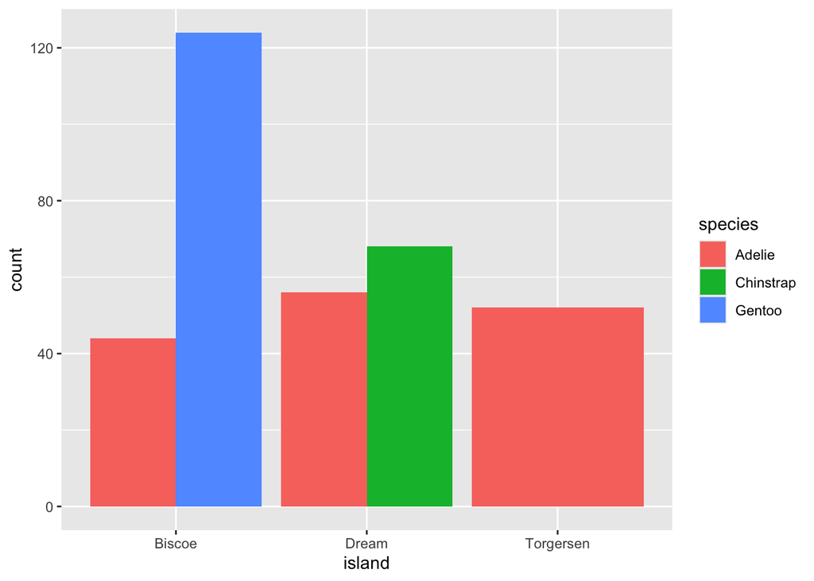

```r
ggplot(penguins, aes(x = island, fill = species)) + geom_bar(position = "dodge")
```

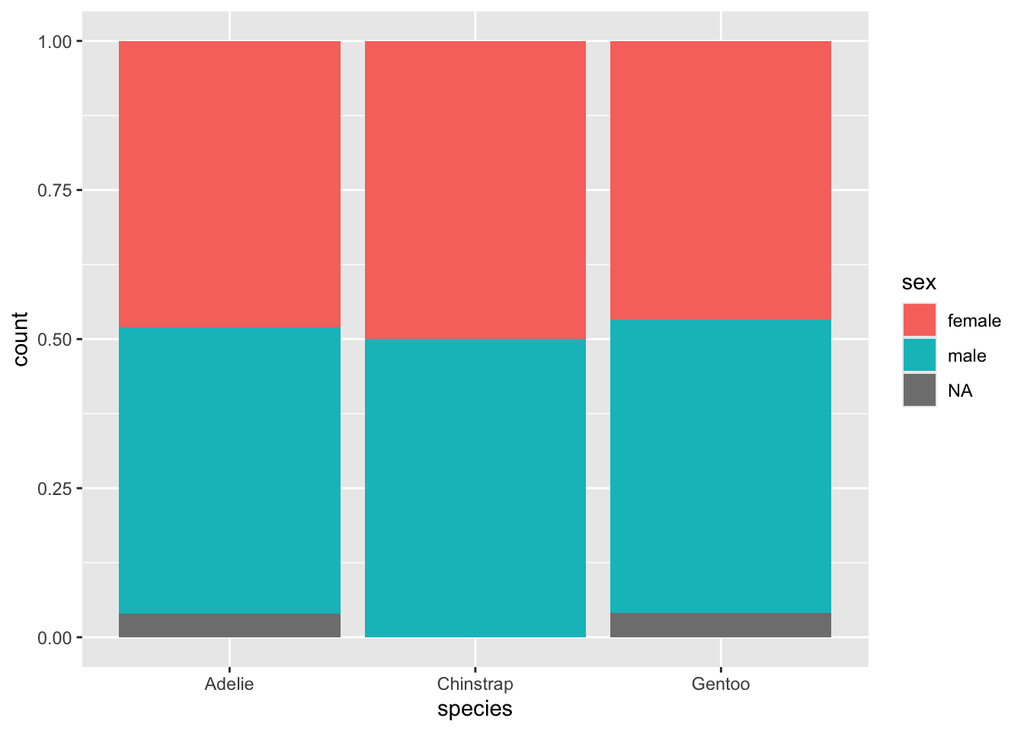

```r
ggplot(penguins, aes(x = species, fill = sex)) + geom_bar(position = "fill")
```

### 🚌 Exercice 10 – Données Titanic

Utilise `titanic::titanic_train`

Variables catégoriques : `Sex`, `Embarked`, `Survived`

Questions : 1. Tableau croisé entre `Sex` et `Survived` 2. Proportion de survie par port d’embarquement (`Embarked`) 3. Représentation graphique croisée `Sex` × `Embarked` × `Survived`

**✅ Solution**

```r
library(titanic)
titanic_train <- titanic::titanic_train

titanic_train %>% count(Sex, Survived)
```

```
     Sex Survived   n
1 female        0  81
2 female        1 233
3   male        0 468
4   male        1 109
```

```r
titanic_train %>% count(Embarked, Survived) %>%
  group_by(Embarked) %>% mutate(p = n / sum(n))
```

```
# A tibble: 7 × 4
# Groups:   Embarked [4]
  Embarked Survived     n     p
  <chr>       <int> <int> <dbl>
1 ""              1     2 1
2 "C"             0    75 0.446
3 "C"             1    93 0.554
4 "Q"             0    47 0.610
5 "Q"             1    30 0.390
6 "S"             0   427 0.663
7 "S"             1   217 0.337
```

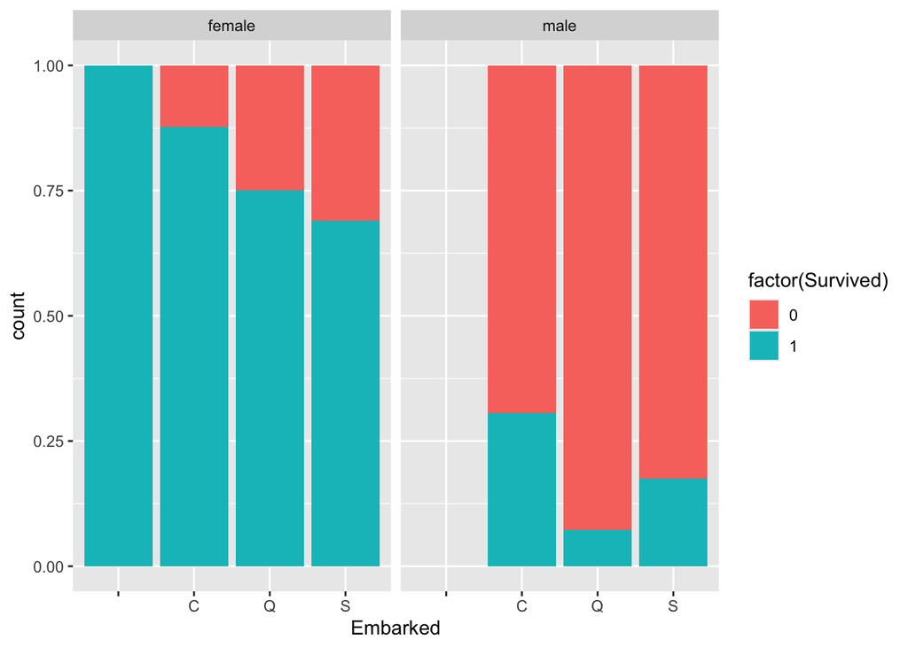

```r
ggplot(titanic_train, aes(x = Embarked, fill = factor(Survived))) +
  geom_bar(position = "fill") +
  facet_wrap(~Sex)
```